[figure not shown]

*Aprendizaje Automático*

*Máster Universitario en Inteligencia Artificial*

# Técnicas de agrupamiento

## Objetivos

- Entender los métodos de clustering K-means, jerárquico y DBSCAN.
- Generar agrupamientos con los métodos de clustering previamente indicados y realizar una comparativa.
- Investigar sobre una técnica de agrupamiento con un caso de uso concreto.

## Descripción de la actividad

El conjunto de datos con el cual vamos a trabajar se encuentra en el siguiente enlace: https://www.kaggle.com/datasets/umerrtx/machine-failure-prediction-using-sensor-data

Este conjunto de datos contiene datos de sensores recopilados de varias máquinas, con el objetivo de predecir fallos de las máquinas con antelación. Incluye una variedad de lecturas de sensores, así como las fallas de la máquina registradas.

### Tareas a realizar

- Clustering
  - Debes completar el código pedido en este notebook y contestar las preguntas finales.
  - Buscar dos artículos científicos (https://scholar.google.es/) con un caso de uso de técnicas de agrupamiento. Los artículos deben estar en revistas científicas, y deben ser posteriores a 2015. No debe utilizar técnicas de Deep Learning.
  - Para cada artículo indicar:
    - Objetivo: cuál es el objetivo de la investigación, es decir a qué problema real está aplicando la detección de anomalías.
    - Técnicas de detección de anomalías empleadas.
    - Principales resultados de la aplicación y de la investigación.

#### Nombre del estudiante

```python
# Coloca en este espacio el nombre del estudiante

# Sergio Gómez Martín (DNI: 53775841 R)

# nota: se entrega en html ya que el pdf no se genera correctamente (queda cortado el final del documento)
```

### Clustering

Comenzamos importando las librerías necesarias y cargando el dataset.

Este archivo contiene 944 mediciones de sensores de diferentes máquinas, contiene una etiqueta de si tiene fallo o no.

Notas:

1. footfall: The number of people or objects passing by the machine.
2. tempMode: The temperature mode or setting of the machine.
3. AQ: Air quality index near the machine.
4. USS: Ultrasonic sensor data, indicating proximity measurements.
5. CS: Current sensor readings, indicating the electrical current usage of the machine.
6. VOC: Volatile organic compounds level detected near the machine.
7. RP: Rotational position or RPM (revolutions per minute) of the machine parts.
8. IP: Input pressure to the machine.
9. Temperature: The operating temperature of the machine.
10. fail: Binary indicator of machine failure (1 for failure, 0 for no failure).

```python
import numpy as np
import pandas as pd
from matplotlib import pyplot as plt
import seaborn as sns

# se carga el dataset, con separados
df = pd.read_csv('data.csv', sep=',')
```

#### ¿Cuántas instancias tiene el dataset?

```python
##indica aquí tu respuesta

tam = df.shape[0]

print(f"Número de instancias es {tam}")
```

```
Número de instancias es 944
```

La pregunta se refiere al número total de filas que tiene el dataset. El total es de 944.

#### ¿Cuál es el tipo de datos predominante en el dataset?

```python
##_indica aquí tu respuesta_

print(df.dtypes)
```

```
footfall       int64
tempMode       int64
AQ             int64
USS            int64
CS             int64
VOC            int64
RP             int64
IP             int64
Temperature    int64
fail           int64
dtype: object
```

Como se puede ver en el fragmento anterior, todas las variables son de tipo int64. Con el atributo dtypes se puede acceder a los tipos de variables que tiene cada una de los atributos del dataset. Este tipo de datos se refiere matemáticamente a números enteros.

#### ¿Son variables continuas o categóricas?

```python
df['tempMode'].nunique()
```

```
8
```

```python
df['IP'].nunique()
```

```
7
```

# *indica aquí tu respuesta*

Atendiendo al tipo de datos, se debería decir que todas son continuas. Sin embargo, en la realidad esto no es así. Es necesario acudir al dataset original para determinar si las variables corresponden o no a categorías. En ocasiones, una variable a priori continua, puede presentar categorías representadas con valores continuos (mediante codificación, por ejemplo).

Observando los datos y la descripción de las características, tempMode es definida como el tipo de ajuste de temperatura de la máquina. En este punto, se genera la hipótesis de que podría ser categórica, queriendo indicar un ajuste entre varios ajustes predefinidos. Observando los datos y el fragmento de código anterior, se ve que tempMode toma valores entre 0 y 7, 8 diferentes. De esta manera, se puede afirmar casi con toda certeza que se trata de una variable categórica.

Por otro lado, fail también es una variable categórica. Sin embargo, no es una variable propiamente del dataset con el que se va a realizar el clustering, ya que es la variable target. Es decir, es la variable (o el cluster en este caso) que se va a tratar de predecir. Es categórica binaria porque representa dos categorías. 1 para indicar que ha habido fallo, 0 para indicar que no.

El resto de variables, aparte de que el rango dde valores es muy alto, en su descripción se puede ver que son medidas físicas de las máquinas, como la temperatura. Hay algunas variables, como IP, que tienen 7 valores diferentes. Sin embargo, mide los niveles de presión, que no necesariamente tiene que tener únicamente 7 categorías y puede estar nada más midiendo la presión en pascales u atmósferas. Siendo conservador, únicamente se puede afirmar que tempMode es una categórica, pues las demás pueden ir asociadas a una medida concreta en alguna unidad de medida.

#### ¿cuáles son los valores mínimo y máximo de la variable 'RP'?

```python
df['RP'].describe()
```

```
count    944.000000
mean      47.043432
std       16.423130
min       19.000000
25%       34.000000
50%       44.000000
75%       58.000000
max       91.000000
Name: RP, dtype: float64
```

### *indica aquí tu respuesta*

El valor mínimo de revoluciones por minuto (RP) es 19, mientras que el valor máximo es 91. Se puede observar con la función describe.

#### Para los algoritmos de clustering el dataset no puede tener instancias con datos faltantes. ¿Tiene este dataset datos faltantes?

```python
df.isnull().sum()
```

```
footfall       0
tempMode       0
AQ             0
USS            0
CS             0
VOC            0
RP             0
IP             0
Temperature    0
fail           0
dtype: int64
```

# *indica aquí tu respuesta*

Como se puede ver en el anterior fragmento, además de viendo la documentación del dataset, no hay ningún valor faltante. En ocasiones, el valor 0 indica que el valor es faltante. Sin embargo, no hya indicios de que en este caso sea así.

#### Elimine la variable fail

```python
#_indica aquí tu respuesta_

df_clustering = df.drop(columns=['fail'])
```

La variable fail indica la variable objetivo o target. Por ello, para el entrenamiento es necesario eliminarla. A modo de no sobreescribir el df original, se ha creado uno nuevo para la clusterización.

#### ¿Es necesario hacer algún tratamiendo adicional sobre los datos?

Sí, antes de proceder con el entrenamiento, es necesario realizar dos tareas:

1. Revisión de outliers o valores atípicos.
2. Normalización.

```python
### PON AQUÍ TU CÓDIGO EN CASO DE QUE SEA NECESARIO HACER ALGÚN TRATAMIENTO ADICIONAL

df_clustering.describe()
```

|  | footfall | tempMode | AQ | USS | CS | VOC | RP | IP | Temperature |
| --- | --- | --- | --- | --- | --- | --- | --- | --- | --- |
| count | 944.000000 | 944.000000 | 944.000000 | 944.000000 | 944.000000 | 944.000000 | 944.000000 | 944.000000 | 944.000000 |
| mean | 306.381356 | 3.727754 | 4.325212 | 2.939619 | 5.394068 | 2.842161 | 47.043432 | 4.565678 | 16.331568 |
| std | 1082.606745 | 2.677235 | 1.438436 | 1.383725 | 1.269349 | 2.273337 | 16.423130 | 1.599287 | 5.974781 |
| min | 0.000000 | 0.000000 | 1.000000 | 1.000000 | 1.000000 | 0.000000 | 19.000000 | 1.000000 | 1.000000 |
| 25% | 1.000000 | 1.000000 | 3.000000 | 2.000000 | 5.000000 | 1.000000 | 34.000000 | 3.000000 | 14.000000 |
| 50% | 22.000000 | 3.000000 | 4.000000 | 3.000000 | 6.000000 | 2.000000 | 44.000000 | 4.000000 | 17.000000 |
| 75% | 110.000000 | 7.000000 | 6.000000 | 4.000000 | 6.000000 | 5.000000 | 58.000000 | 6.000000 | 21.000000 |
| max | 7300.000000 | 7.000000 | 7.000000 | 7.000000 | 7.000000 | 6.000000 | 91.000000 | 7.000000 | 24.000000 |

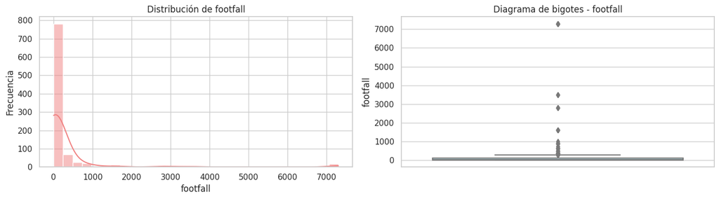

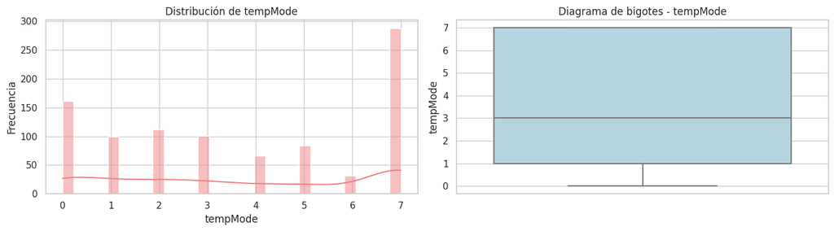

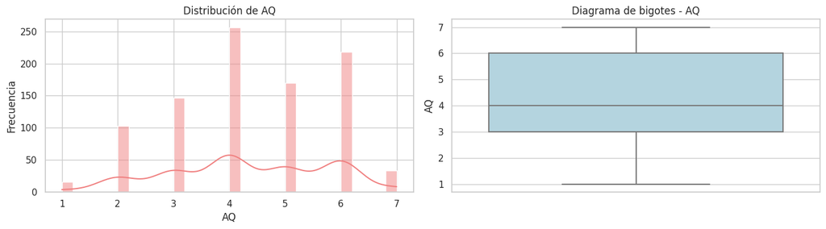

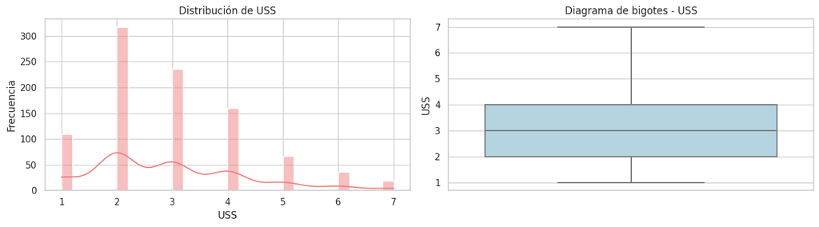

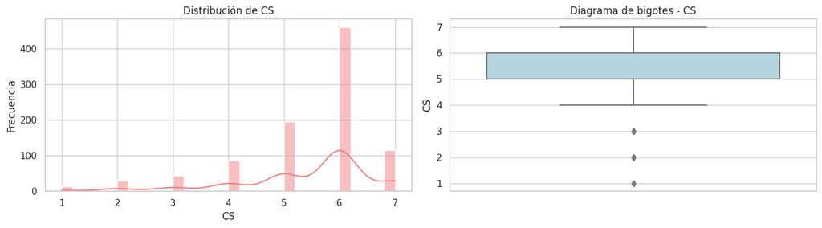

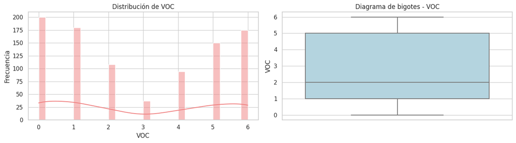

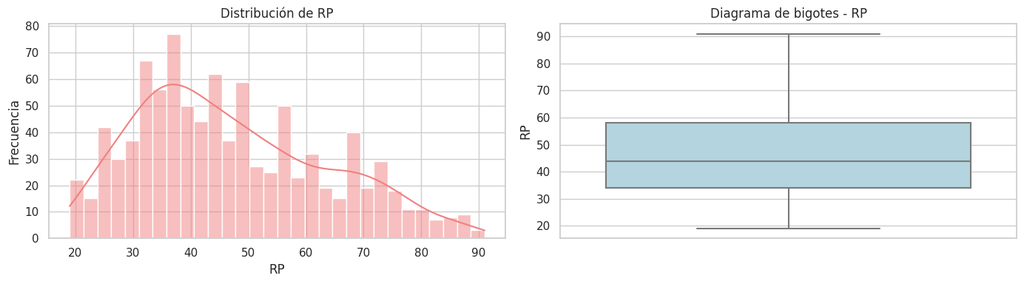

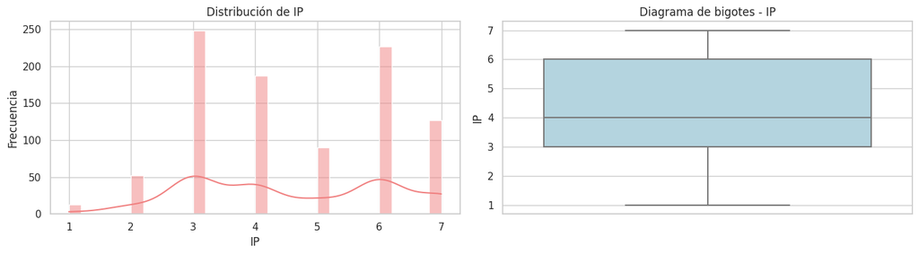

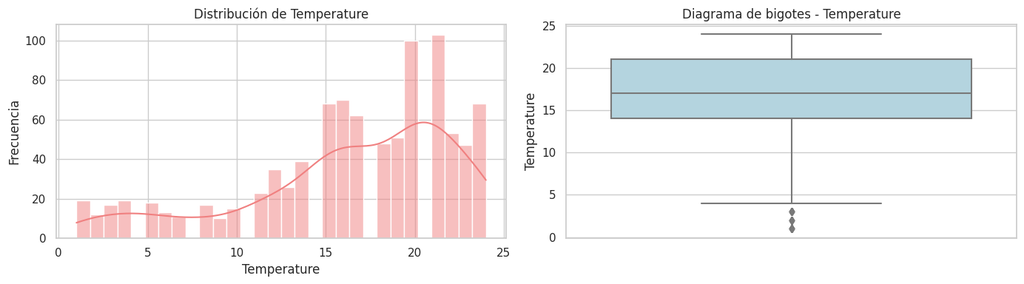

```python
sns.set(style="whitegrid")
plt.rcParams["figure.figsize"] = (12, 5)

for col in df_clustering.columns:
    fig, axes = plt.subplots(1, 2, figsize=(14, 4))

    sns.histplot(df[col], kde=True, bins=30, color='lightcoral', ax=axes[0])
    axes[0].set_title(f'Distribución de {col}')
    axes[0].set_xlabel(col)
    axes[0].set_ylabel('Frecuencia')

    sns.boxplot(y=df[col], color='lightblue', ax=axes[1])
    axes[1].set_title(f'Diagrama de bigotes - {col}')
    axes[1].set_ylabel(col)

    plt.tight_layout()
    plt.show()
```

Se puede observar, atendiendo a los estadísticos anteriores, que footfall es la que más tendencia tiene hacia valores anómalos. Las demás presentan estadísticos y distribuciones aceptables, pese a la presencia de algún valor fuera del diagrama de bigotes. Estos valores altos pueden afectar muy negativamente a la clusterización con k-means (luego se verá que a dbscan no le afectan así los outliers), ya que se basa en distancias.

La primera opción que puede surgir es eliminarlo. Sin embargo, no se tiene suficiente conocimiento de si se pueden elimianr estos outliers. Por ello, no se puede decidir eso.

Por ello, tras revisar distintaas técnicas, como el truncado o el mapeo al percentil 95, se ha decidido por realizar una transformación logarítmica, de manera que se ajusten los valores a un rango más pequeño.

```python
from sklearn.preprocessing import PowerTransformer

pt = PowerTransformer(method='yeo-johnson', standardize=False)

pt.fit(df_clustering[['footfall']])
```

```
PowerTransformer(standardize=False)
```

```python
df_clustering['footfall'] = pt.transform(df_clustering[['footfall']])
```

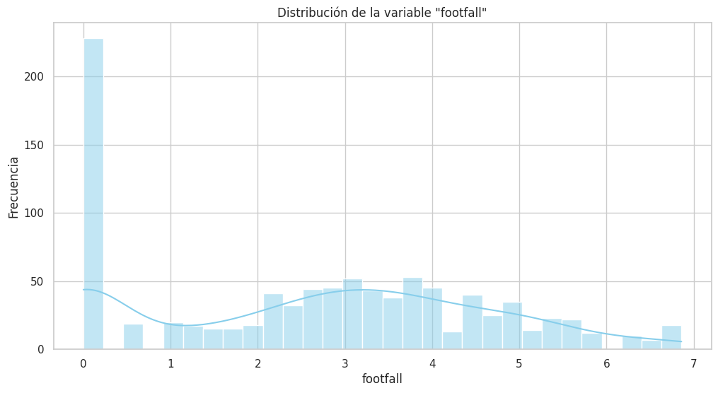

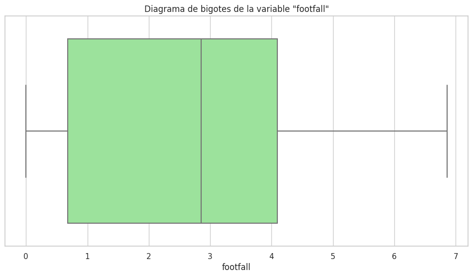

```python
plt.figure(figsize=(12, 6))
sns.histplot(df_clustering['footfall'], kde=True, bins=30, color='skyblue')
plt.title('Distribución de la variable "footfall"')
plt.xlabel('footfall')
plt.ylabel('Frecuencia')
plt.show()

plt.figure(figsize=(12, 6))
sns.boxplot(x=df_clustering['footfall'], color='lightgreen')
plt.title('Diagrama de bigotes de la variable "footfall"')
plt.xlabel('footfall')
plt.show()
```

Se puede ver que ha quedado mucho mejor la distribución utilizando esta transformación logarítmica, así que se mantendrá.

El siguiente paso será aplicar un normalizador para poder trabajar con k-means. K-means trabaja con distancias, por lo que normalizarlos es importante para que las diferentes escalas no afecten a su rendimiento.

Para escalar, se ha decidido usar MinMaxScaler. Esto es porque StandardScaler suele estar dedicado a escalados donde las distribuciones de las variables son gaussianas (normales). En este caso, como se puede ver previamente en este NB, muchas no cumnplen esta condición, por lo que se propondrá el uso de MinMaxScaler, apto para otro tipo de distribuciones.

La transformación se hará dentro del siguente bloque de K-Means.

## K-Means

```python
# escalado previo para utilizar KMeans

from sklearn.preprocessing import MinMaxScaler

df_scaled = df_clustering.copy()

scaler = MinMaxScaler()

df_scaled[df_scaled.columns] = scaler.fit_transform(df_scaled[df_scaled.columns])
```

Crea 10 modelos de KMeans y entrénalos. Haciendo uso del método indicado para saber el número ideal de clústeres.

KMeans tiene la limitación de que es necesario indicar el número de clústers para el entrenamiento. En este caso, no se tiene conocimiento a priori para decidir esto. Para evaluar el número de clústeres, se va a comenzar utilizando el método del codo. Este entrena modelos utilizando diferente k y mide la inercia, es decir, la suma la cuadrado entre los puntos y los centroides. Este determina el pùnto en el que añadir más clústers no mejoro la compacidad de los mismos. Posteriormente, y a modo de validación del método del codo, se hará una evaluación basada en el coeficiente de silueta, que mide el grado de cohesión y separación de los clústeres entre sí. Este indica cómo de bueno es el agrupamiento. Utilizando los dos métodos de manera complementaria, se podrá tomar una mejor decisión sobre el número de clústers óptiomo en el entrenamiento.

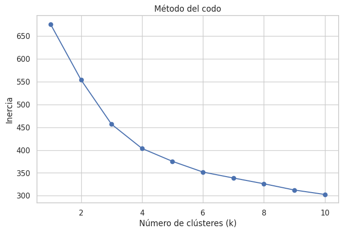

```python
# Metodo del codo

from sklearn.cluster import KMeans

inertias = []
X = df_scaled.values

for k in range(1, 11):
    kmeans = KMeans(n_clusters=k, random_state=42)
    kmeans.fit(X)
    inertias.append(kmeans.inertia_)

plt.figure(figsize=(8, 5))
plt.plot(range(1, 11), inertias, marker='o')
plt.title('Método del codo')
plt.xlabel('Número de clústeres (k)')
plt.ylabel('Inercia')
plt.grid(True)
plt.show()
```

Se puede apreciar el codo en 3 o en 4, aunque no parece ser muy claro. Se comprobará a continuación con el coeficiente de silueta.

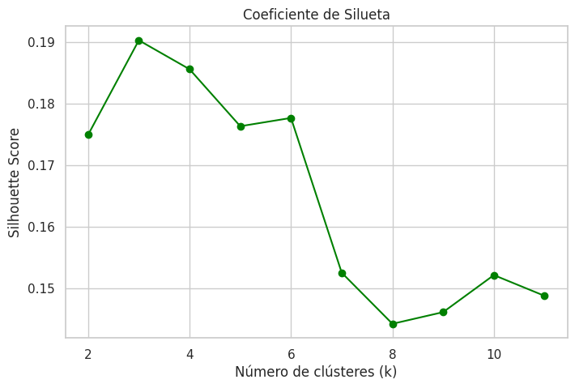

```python
# Metodo de la silueta

from sklearn.metrics import silhouette_score

silhouette_scores = []

for k in range(2, 12):
    kmeans = KMeans(n_clusters=k, random_state=42)
    labels = kmeans.fit_predict(X)
    score = silhouette_score(X, labels)
    silhouette_scores.append(score)

plt.figure(figsize=(8, 5))
plt.plot(range(2, 12), silhouette_scores, marker='o', color='green')
plt.title('Coeficiente de Silueta')
plt.xlabel('Número de clústeres (k)')
plt.ylabel('Silhouette Score')
plt.grid(True)
plt.show()
```

Gracias al coeficiente de silueta, se puede confirmar con que el valor óptimo de k a priori es 3. Será el que se utilizará para el entrenamiento.

Ahora toca interpretar lo que Kmeans ha realizado. Recordemos que el objetivo de KMeans es encontrar patrones en los datos.

Lo primero que vamos a realizar es un gráfico para visualizar los clústers que ha creado con base en las variables utilizadas para crearlos.

```python
kmeansmodel = KMeans(n_clusters=3, init='k-means++', random_state=42)

kmeansmodel.fit(X)
```

```
KMeans(n_clusters=3, random_state=42)
```

```python
import plotly.express as px

clusters = pd.DataFrame(X,columns=df_scaled.columns)
clusters['label'] = kmeansmodel.labels_
polar = clusters.groupby("label").mean().reset_index()
polar = pd.melt(polar,id_vars=["label"])
fig4 = px.line_polar(polar, r="value", theta="variable", color="label", line_close=True,height=800,width=600)
fig4.show()
```

[interactive chart not shown]

Se puede observar gracias al gráfico polar que existen diferencias entre los clusters. Por ejemplo, se encuentra que el label 1 tiene un tempMode muy alto un VOC bajo, mientras que el 0 tiene un VOC muy alto. Aparte de esta, AQ también muestra bastante variación entre los clústers. Se va a probar a dibujar un gráfico de dispersión

```python
import plotly.express as px

clusters['label'] = kmeansmodel.labels_

fig = px.scatter(clusters, x='tempMode', y='VOC', color='label',
                 title="Clusters según tempMode y VOC",
                 labels={'tempMode': 'tempMode', 'VOC': 'VOC'},
                 height=800, width=600)

fig.show()
```

[interactive chart not shown]

Se puede apreciar las diferencias entre los clusters, estando bien separados. Cabe mencionar que la regularidad en los resultados se debe al uso de MinMaxScaler, que escala todos los valores entre 0 y 1. Sin embargo, se puede apreciar que los clústeres es´tan bien diferenciados.

## DBSCAN

```python
import numpy as np
import pandas as pd
import seaborn as sns
import matplotlib.pyplot as plt
from sklearn.cluster import AgglomerativeClustering, DBSCAN
from sklearn.preprocessing import StandardScaler
from sklearn.cluster import KMeans
from sklearn import datasets
```

cabe mencionar en primer lugar que dbscan es robusto a outliers, y no se necesita de limpieza previa. Por ello, se va a volver a cargar el dataset de manera que se pueda evaluar la manera en la que el algoritmo maneja por su cuenta los outliers. Al ofrecer un conjunto de puntos que considera como ruido, es el propio algoritmo el que detecta estos valores anómalos. Sí es importante el escalado, ya que dbscan se basa en distancias y en caso de no escalar podría haber resultados alterados.

```python
df = pd.read_csv('data.csv', sep=',')
df_clustering = df.drop(columns=['fail'])
```

La gran ventaja que ofrece dbscan sobre kmeans es que en este caso no es necesario decirle al modelo el número de clusters, ya que lo hace de manera automática. Además, para kmeans se tuvo que realizar un procesado de valores atípicos, lo cual no es necesario en dbscan. DBSCAN también ofrece robustez ante formas no comunes en los clústeres, pues puede encontrar clusteres de forma arbitraria y compleja.

Los dos hiperparámetros que se deben tener en cuenta en el algoritmo dbscan son epsilon, a partir de ahora 'e', que es la distancia maxima entre dos puntos vecinos; y el minimo numero de puntos (MinPts), que como su nombre indica, se refiere al minimo numero de puntos que debe tener un grupo para considerearse denso.

```python
from sklearn.preprocessing import MinMaxScaler

df_scaled = df_clustering.copy()

scaler = MinMaxScaler()

df_scaled[df_scaled.columns] = scaler.fit_transform(df_scaled[df_scaled.columns])

X = df_scaled.values
```

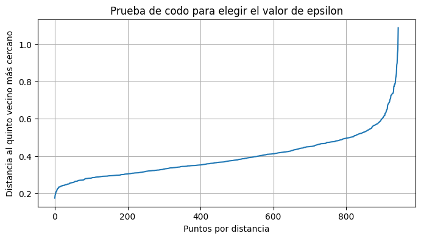

```python
#### Realiza una búsqueda de los mejores hiperparámetros para el algoritmo

from sklearn.neighbors import NearestNeighbors
import numpy as np
import matplotlib.pyplot as plt

X = df_scaled.values

min_samples = 5

neighbors = NearestNeighbors(n_neighbors=min_samples)
neighbors_fit = neighbors.fit(X)

distances, indices = neighbors_fit.kneighbors(X)

distances_k = np.sort(distances[:, min_samples-1])

plt.figure(figsize=(8,4))
plt.plot(distances_k)
plt.xlabel('Puntos por distancia')
plt.ylabel(f'Distancia al quinto vecino más cercano')
plt.title('Prueba de codo para elegir el valor de epsilon')
plt.grid(True)
plt.show()
```

El primer paso será emplear la prueba del codo para valorar qué valor de epsilon es mejor. En este caso, el eje x indican los diferentes puntos ordenados por distancia, y en el y la distancia al quinto vecino más cercano de cada uno de los puntos. Al igual que la prueba del codo que se utilizó en kmeans, se busca un cambio brusco en la pendiente. En este caso, la curva es bastante poco pronunciada hasta un punto, que se va a fijar en 0.6 aproximadamente (aunque quizá esté entre 0.55 y 0.6). Se ha probado un minpts de 5, y se han probado varios valores como 2, 5 o 10, sin modificaciones significativas en el gráfico. Se ha decidido mostrar la prubea con valor igual a 5.

El siguiente paso será valorar qué valor de minpts se comporta mejor suponiendo que se ha fijado un e de 0.6. Este valor define el num de puntos que debe haber en el radio e escogido para que un punto sea considerados como nucleo de cluster. En este caso, se ha implementado una lógica que en primer lugar comprueba para varios valores de min samples el valor de silueta. Además, a la hora de dar los resultados se realiza una comprobación pues si se genera un unico cluster se omite el resultado. POr último, se tendrá en consideración aquel resultado con mayor valor de silueta. También se realiza un procesado en el que se eliminan los valores que el modelo haya catalogado como ruido para valorar cuántos clusters reales ha generado.

```python
# Pon aquí tu código

from sklearn.cluster import DBSCAN
from sklearn.metrics import silhouette_score
import numpy as np

X = df_scaled.values
eps = 0.6
min_samples_range = range(3, 11)

for min_pts in min_samples_range:
    dbscan = DBSCAN(eps=eps, min_samples=min_pts)
    labels = dbscan.fit_predict(X)

    mask = labels != -1
    n_clusters = len(set(labels[mask]))

    if n_clusters < 2:
        print(f"min_samples={min_pts}: solo {n_clusters} clúster")
        continue

    score = silhouette_score(X[mask], labels[mask])
    print(f"min_samples={min_pts} → clústers: {n_clusters}, Valor de silueta: {score:.3f}")
```

```
min_samples=3 → clústers: 3, Valor de silueta: 0.179
min_samples=4 → clústers: 2, Valor de silueta: 0.232
min_samples=5: solo 1 clúster
min_samples=6: solo 1 clúster
min_samples=7: solo 1 clúster
min_samples=8: solo 1 clúster
min_samples=9: solo 1 clúster
min_samples=10: solo 1 clúster
```

```python
#### Entrenar el algoritmo DBSCAN con los hiperparámetros encontrados
```

```python
# Pon aquí tu código

from sklearn.neighbors import KDTree
from sklearn.cluster import DBSCAN

tree = KDTree(X, leaf_size=30)
dbscan = DBSCAN(eps=0.6, min_samples=3, algorithm='kd_tree')
dbscan.fit(X)
labels = dbscan.labels_
```

```python
print(np.unique(labels, return_counts=True))
```

```
(array([-1,  0,  1,  2]), array([ 17, 918,   6,   3]))
```

```python
#### Elegir dos variables para visualizar los clústeres
```

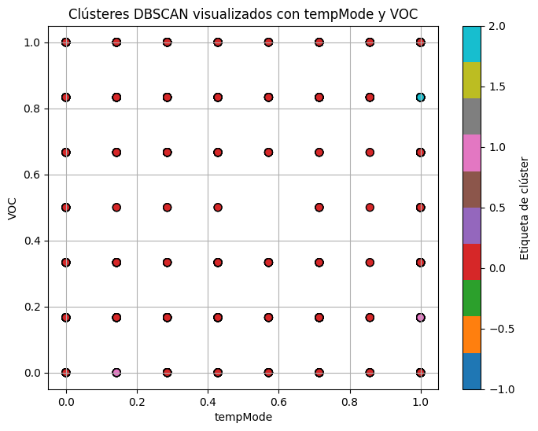

```python
import matplotlib.pyplot as plt

df_vis = df_scaled.copy()
df_vis["cluster"] = labels

plt.figure(figsize=(8, 6))
scatter = plt.scatter(
    df_vis["tempMode"],
    df_vis["VOC"],
    c=df_vis["cluster"],
    cmap="tab10",
    s=50,
    edgecolor="k"
)

plt.title("Clústeres DBSCAN visualizados con tempMode y VOC")
plt.xlabel("tempMode")
plt.ylabel("VOC")
plt.colorbar(label="Etiqueta de clúster")
plt.grid(True)
plt.show()
```

```python
import numpy as np
print(np.unique(labels, return_counts=True))
```

```
(array([-1,  0,  1,  2]), array([ 17, 918,   6,   3]))
```

Se puede observar que el cluster azul es tremendamente pequeño. Casi parece que todos los datos pertenecen al mismo cluster. Se probó tanto con min samples igual a 3 y a 4, que fueron los que dieron resultados positivos de silueta. Ninguno de los dos hizo clusteres equilibrados en cuanto a tamaño, por lo que se decidió incluir el que hace 3 clusteres, aunque tenga un valor de silueta inferior.

## Dendrograma

```python
import numpy as np
import pandas as pd
import seaborn as sns
import matplotlib.pyplot as plt
from sklearn.cluster import AgglomerativeClustering, DBSCAN
from sklearn.preprocessing import StandardScaler
from sklearn.cluster import KMeans
from sklearn import datasets

df = pd.read_csv('data.csv', sep=',')
df_clustering = df.drop(columns=['fail'])
```

El primer paso para este apartado será aplicar un clustering aglomerativo o botton up, que empieza de grupos más pequeños hasta formar grupos más grandes. Se aplicará el algoritmo para después mostrar el dendograma con el objetivo de obtener el número de clústeres adecuado. Cabe mencionar que este tipo de clusterng no es robusto a outliers ya que no detecta los puntos catalogados como ruido. Por ello, se va a realizar la limpieza de outliers que se realizó para kmeans

```python
from sklearn.preprocessing import PowerTransformer

pt = PowerTransformer(method='yeo-johnson', standardize=False)

pt.fit(df_clustering[['footfall']])

df_clustering['footfall'] = pt.transform(df_clustering[['footfall']])
```

```python
from sklearn.preprocessing import MinMaxScaler

df_scaled = df_clustering.copy()

scaler = MinMaxScaler()

df_scaled[df_scaled.columns] = scaler.fit_transform(df_scaled[df_scaled.columns])
```

```python
#### Aplica el algoritmo de AgglomerativeClustering a los datos
```

```python
## Pon aquí tu código
from sklearn.cluster import AgglomerativeClustering
from scipy.cluster.hierarchy import dendrogram
```

```python
clustering_model = AgglomerativeClustering(distance_threshold=0, n_clusters=None, linkage='ward')
clustering_model = clustering_model.fit(df_scaled)
```

```python
#### Realiza un análisis de cuál es el número ideal de clústeres y explique el porqué de su elección
```

Para realizar el análisis del número de clusters se va a realizar un dendrograma

```python
def plot_dendrogram(model, **kwargs):
    # Create linkage matrix and then plot the dendrogram
    # Create the counts of samples under each node
    counts = np.zeros(model.children_.shape[0])
    n_samples = len(model.labels_)
    for i, merge in enumerate(model.children_):
        current_count = 0
        for child_idx in merge:
            if child_idx < n_samples:
                current_count += 1  # Leaf node
            else:
                current_count += counts[child_idx - n_samples]
        counts[i] = current_count

    linkage_matrix = np.column_stack([model.children_, model.distances_, counts]).astype(float)

    # Plot the corresponding dendrogram
    dendrogram(linkage_matrix, **kwargs)

    #plt.axline(XXXX, color = 'r', linestyle = '--')
    plt.title("Hierarchical clustering")
    plt.ylabel("Distance")
    plt.xlabel("Texts")
    plt.show()
```

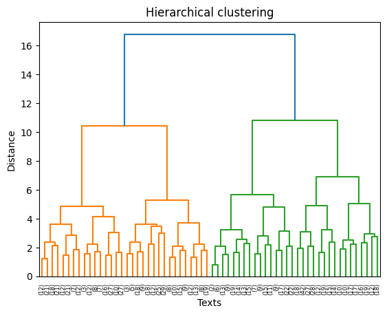

```python
plot_dendrogram(clustering_model, truncate_mode='level', p=5)
```

Como se puede apreciar, el número óptimo de clústers es dos, que se ven bien diferenciados (uno en verde y otro en naranja). El siguiente paso será analizar el comportamiento del modleo ya habiendo decidido el número óptimo de clústers.

```python
#### Aplica de nuevo el clustering jerárquico con el número de clústeres elegido y crea un dataframe con los datos y las etiquetas otorgadas por el algoritmo.
```

```python
# Now, decide the number of clusters based on the dendrogram
optimal_clusters = 2
final_clustering_model = AgglomerativeClustering(n_clusters=optimal_clusters, linkage='ward')
cluster_labels = final_clustering_model.fit_predict(df_scaled)

# Add cluster labels to the original data
df_clustering['cluster'] = cluster_labels
df_clustering['label'] = df['fail']
```

```python
pd.crosstab(df_clustering['label'], df_clustering['cluster'], rownames=['Etiqueta real'], colnames=['Cluster asignado'])
```

| Cluster asignado Etiqueta real | 0 | 1 |
| --- | --- | --- |
| 0 | 469 | 82 |
| 1 | 28 | 365 |

[figure not shown]

```python
import seaborn as sns
import matplotlib.pyplot as plt

sns.countplot(data=df_clustering, x='cluster', hue='label')
plt.title("Distribución de clases por clúster")
plt.xlabel("Cluster asignado")
plt.ylabel("Número de muestras")
plt.legend(title="Etiqueta real")
plt.show()
```

En el gráfico anterior se observa que se ha comportado mejor para el clúster 0, ya que ha catalogado bien prácticamente todas las instacias.. Para el clúster 1 es donde quizá ha fallado un poco más, aunque los resultados siguen siendo significativamente buenos.

## Análisis

#### Realiza un análisis detallado de cada uno de los grupos generados por los algoritmos aplicados anteriormente y decide cuál es el mejor método para el conjunto de datos.

Utiliza gráficos o tablas para apoyar tus conclusiones

En esta sección se solicita un análisis en profundidad de los resultados aportados por cada uno de los algoritmos. Sin embargo, esta tarea ya se ha ido haciendo conforme se han ido implmentando los diferenetes modelos, así como gráficas y tablas de apoyo para ir viendo el comportamiento de los mismos.

Por ello, esta última sección presentará las conclusiones derivadas de todos estos análisis y se decidirá cuál ha sido el algoritmo que parece haber tenido mejor rendimiento.

Por último, el clustering jerárquico parece haber sido el mejor en cuanto a comportamiento. Se ve en la matriz de confusión y en la gráfica de apoyo que clasificó muy bien las diferentes instancias. En este ejercicio, se toma la decisión de que este es el mejor algoritmo en cuanto a comportamiento y también en cuanto a sencillez, ya que no es necesario ese ajuste óptimo de hiperparámetros que puede cargar mucho computacionalmente en un problema donde el dataset tenga un tamaño y dimensionalidad mayor, más ajustado a un caso real.

## Artículos de investigación

Para la realización de este ejercicio se han escogido dos artículos con objetivos diferentes para acaparar un espectro lo mayor posible de soluciones basada en clustering. Se presentará en primer lugar ca artículo mediante su referencia en formato APA, y posteriormente se dividirá la explicación del mismo entre resumen, objetivos, técnicas utilizadas y resultados. De esta manera, se presenta cada uno de forma que se pueda comprender de manera estructurada el avance presentado.

#### Artículo 1

```python
# Coloca en este espacio el análisis del artículo 1
```

El primer artículo a analizar será uno denominado "Statistical Inference for Clustering-based Anomaly Detection".

Su referencia, en formato APA, es la siguiente:

Nguyen Thi Minh Phu, Duong Tan Loc, & Vo Nguyen Le Duy. (2025). Statistical Inference for Clustering-based Anomaly Detection. arXiv:2504.18633. https://arxiv.org/abs/2504.18633

1. Resumen

El artículo presentado toma en consideración un problema común en el aprendizaje automático: la detección de anomalías. Indica que existe un reto en este tipo de problemas ya que suele existir una tasa mayor de falsos positivos, lo que hace muy complicado validar estadísticamente que un punto de un hiperplano sea detectado correctamente como una anomalía. En muchos sistemas, comenta el artículo, las técnicas de clustering se utilizan para identificar grupos de dats con similitudes, y las observaciones fuera de estos grupos se consideran anomalías. Sin embargo, consideran que estas técnicas clásicas de aprendizaje no supervisado no son lo suficientemnte fiables para represetar una situación real.

2. Objetivos:

Con la problemática anterior, el objetivo del artículo es desarrollar una metodología estadística lo suficientemente robusta que permita controlar la tasa de falsos positivos durante el uso de técnicas de clustering. A este método se le llama SI-CLAD (en base al t´tiulo del artículo). Se buscó utilizar técnicas de inferencia estadística para garantizar que las anomalías realmente lo son y no es solamente ruido o errores en los datos. El objetivo del sistema es muy ambicioso, ya que hay aplicaciones en las que este problema es crucial, como los diagnósticos médicos

3. Técnicas

Se presneta en este apartado la innovación propuesta, el sistema SI-CLAD, que combina técnicas clásicas de clustering con un paso de análisis de anomalía mediante inferencia estadística selectiva, que controla esta tasa de falsos positivos (FP). Dando más contexto, esta técnica aplica un algoritmo de clustering tradicional. En el artículo se menciona DBSCAN para esta tarea. Con esto se obtiene los grupos o clusters de los datos. Después, se calcula para cada punto una medida específica que cuantifica cómo de probable es que el punto pertenezca al cluster al que fue asignado o que esté fuera de cualquier cluster. Es en este punto donde se ajustan las pruebas estadísticas para corregir el sesgo que pudo introducir la técnica de clustering, y para ello se usa inferencia selectiva. Esta etapa genera valores p ajustados para cada uno de los puntos. Por último, se fija un nivel umbral de significancia y se marca como anomalía aquellos puntos que son menores que este umbral. El artículo incluye tanto las fórmulas aplicadas como el pseudocódigo de estos algoritmos.

4. Resultados

Se comparó el algoritmo con te´cnicas de clustering clásicas, y se descubrió que SI-CLAD ofrece más robustez ante falsos positivos, lo que era precisamente el objetivo principal del artículo. Se demuestra por tanto que el método propuesto tiene una mejor actuación en el problema de detección de anomalías.

#### Artículo 2

```python
# Coloca en este espacio el análisis del artículo 1
```

La referencia en formato APA del segundo artículo es:

Lu, C. X., Mittal, T., Chen, C. H., Li, A. Y., Worthen, K., Sargent, B. A., Lisse, C. M., Sloan, G. C., Hines, D. C., Watson, D. M., Rebollido, I., Ren, B. B., & Green, J. D. (2025). Sequencing Silicates in the IRS Debris Disk Catalog I: Methodology for Unsupervised Clustering. arXiv:2501.01484 https://arxiv.org/abs/2501.01484

Para seleccionar este artículo, se ha escogido el otro caso de uso más común de la clusterización aparte de la detección de anomalías. Esto es la catalogación. Esta es un tipo de tarea de clasificación en la que se busca catalogar un conjunto de datos en grupos diferentes.

1. Resumen

El artículo presenta la problemática de catalogación de discos de escombros astronómicos. Por ello, introduce un nuevo método para la calsificación de estos basándose en espectros infrarrojos que indican su composición. También se defiende que es fundamental estudiar la composición de estos discos para estudiar de manera fiable los procesos planetarios y de formación de estrellas. Para el artículo, los investigadores se centran únicamente en técnicas de aprendizaje no supervisado (como además indica el enunciado de esta actividad) para descubrir patrones en los datos. La propuesta final sería la herramiente CLUES ((CLustering UnsupErvised with Sequencer). Esta combina varias técnicas de clustering y medidas de distancia entre espectros. Los clusters creados a partir de la utilización de CLUES permitirían categorizar los discos de escombros según su composición química y su evolución. Esto sería un gran avance para el análisis masivo de grandes bases de datos astronómicos.

2. Objetivos

El objetivo principal d la investigación es, como se ha indicado, crear una herramienta que permita agrupar los espectros infrarrojos (que presentan la composición) de los discos sin necesidad de supervisión ni etiquetas previas. Como objetivos secundarios pero también implícitos en el anterior, está la detección de patrones en las composiciones de los discos que permitan diferenciar cada tipo.

3. Técnicas

El método CLUES no utiliza un único algoritmo. Este ejecuta varios algoritmos clásicos de manera paralela o secuencialmente. Estos algoritmos son kmeans, clustering jerarquico o dbscan (ya presentados a lo largo de esta actividad). Posteriormente, en lugar de medir la similitud entre clusters con una sola métrica, se utilizan varias distancias en diferentes escalas o resoluciones. Dos de las principales son la distancia global, que mide la distancia de todo el espectro de forma grupal, o la distancia local, que se centra en segmentos concretos. Esta segunda es la que puede indicar compuestos particulares. Con el uso de difernetes medidas puede capturar de manera simultánea patrones muy específicos y generales. Después, los datos se normalizan con el objetivo de eliminar sesgos y y se aplican filtros para reducir el ruido al menor posible. El siguiente paso será repetir los agrupamientos con diferentes parámetros para comprobar que los clústers son robustos y estables. Es decir, que cambiando parámetros los clústeres siguen siendo los mismos. El último paso de CLUES será ordenar los clústeres resultantes en función de sus similitudes con el objetivo de facilitar aún más su interpretación y la detección de tendencias en los datos.

4. Resultados

El método encontró en los datos varios grupos de discos con composiciones parecidas. Entre ellos, encontró discos ricos en ciertos tipos de silicatos, como piroxeno, y otros con composiciones más variadas. Además, se dieron indicios de que los patrones están relacionados con etapas evoluctivas, lo que atisba hipótesis sobre la manera en la que los discos van cambiando su composición a lo largo del tiempo. La herramienta superó en precisión y sobre todo en estabilidad a modelos basados en un sólo algoritmo, aunque también el factor de evaluación multiescala jugó un papel importante en esta mejoría. Todo ello permitirá poder hacer buenas catalogaciones sin necesidad de supervisión ni trabajo manual.